# R Beginners Course 2025

Introduction to R and Basic Programming Concepts

Dr. Debasish Mukherjee, Dr. Ulrike Goebel, Dr. Ali Abdallah

Bioinformatics Core Facility CECAD

2025-05-13

**Session 1 :: Background & R Basics**

## The Lifeline of R

- R is an offspring of the **`S programming language`**
- S was a pioneer in **`making exploratory data analysis easy`**
  - make existing algorithms available in user friendly **`functions`**
  - provide accessible **`function documentation`**
  - provide interactive **`graphics`** devices

## The Lifeline of R

- R was born as an implementation of S in 1993, because **`native S had gone commercial`**
- Being free and encouraging contributions by the user community, **`R can easily "evolve" to adapt to new needs and trends`**
- **`Data driven science`** , including the genome projects, was the perfect “niche” which R could successfully claim for itself
- Indeed the **`Bioconductor project`** was initiated by one of the founders of R

## The Lifeline of R

- The **`RStudio (now: Posit)`** company is gaining increasing influence on the evolution of the language
  - its **`Integrated Development Environment (IDE)`** is increasingly used by people doing data analysis with R
  - Posit is actively developing and promoting the **`tidyverse`**, which is both a special style and a code repository for the analysis of **`data tables`**
- Currently there is quite some **`evolutionary pressure`** for change of the language!

## The Iris Data of Edgar Anderson and Ronald A. Fisher

### – Some Background Information on Our Practice Dataset

We will use the **`iris dataset of floral traits`** for practicing throughout the course:

```r
data("iris") ## Load the data
head(iris, n=3)   ## glimpse at the first 3 lines
```

```
  Sepal.Length Sepal.Width Petal.Length Petal.Width Species
1          5.1         3.5          1.4         0.2  setosa
2          4.9         3.0          1.4         0.2  setosa
3          4.7         3.2          1.3         0.2  setosa
```

It contains data on **`three species`**,  
with **`50 observations`** each:

```r
table(iris$Species) ## species in dataset
```

```
    setosa versicolor  virginica
        50         50         50
```

[(see source page)](https://www.fs.usda.gov/wildflowers/beauty/iris/flower.shtml)

## The Iris Data of Edgar Anderson and Ronald A. Fisher

### – Some Background Information on Our Practice Dataset

- Data published by **Ronald A. Fisher** in 1936
- Statistician and co-founder of **population genetics**
- Plants collected by **Edgar Anderson**
  - I. setosa and I. versicolor in 1935,  
    in the same natural habitat
  - I. virginica likely in 1926,  
    at a different place
- Field botanist with a focus on **speciation mechanisms**

[(see source page)](https://www.fs.usda.gov/wildflowers/beauty/iris/flower.shtml)

## The Iris Data of Edgar Anderson and Ronald A. Fisher

### – Some Background Information on Our Practice Dataset

- Both men were involved in the making of the **Modern/Evolutionary Synthesis**, with complementary central tenets:
  - R. A. Fisher: **Model evolutionary processes from the known facts of genetics**
  - E. Anderson: **Observe the real dynamics of (plant) populations, in order to understand the role of genetics in evolution**

[(see source page)](https://www.fs.usda.gov/wildflowers/beauty/iris/flower.shtml)

## The Iris Data of Edgar Anderson and Ronald A. Fisher

### – Some Background Information on Our Practice Dataset

- Edgar Anderson suspected that I. versicolor may be an allopolyploid hybrid:  
  **I. versicolor =**  
  **I. setosa (2n) x I. virginica (4n)**  
  (confirmed by **Lim et al. 2007**)
- This may have supported the establishment of the species, by preventing back-crossing to its parents.
- Fisher applied his **Linear Discriminant Analysis** technique to Anderson’s data, in order to test the **hypothesis of additive gene action**:  
  if true, versicolor should be twice as similar to virginica than to sertosa!

[(see source page)](https://www.fs.usda.gov/wildflowers/beauty/iris/flower.shtml)

## Digression: Software is Usually Built From Bits and Pieces

- … they come under the names of subroutines, macros, **functions** …
- … in code, they **are used like ’commands**’:

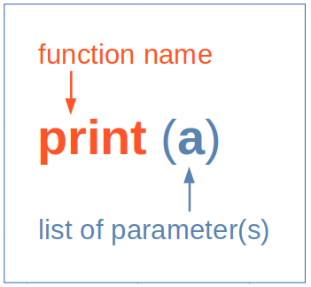

- Actually the **function name invokes a piece of hidden code**
- … hiding complexity
- … yet allowing to easily access complex algorithms
- … and to make local extensions of a language

[figure not shown]